DDS · UPC / S4

1 / 1

Data Driven Security · Part 1 · S4

# Exploració, gràfics i ML

Les dades de ciberseguretat són els estàndards. Avui les mires amb gràfics, veus com aprèn un model a partir d'elles, i construeixes el graf del cas amb mitre.

Data

dijous 03/12/2026

Horari

18:30–21:30

Docent

Arnau

Competència

C.E.1, C.E.3 · del cas al model

Índex temporal

## Tres hores, sis blocs

T = teoria · P = pràctica. En acabar, saps explicar un model com una funció apresa, has explorat el cas amb ggplot2 i surts amb l'exercici-pont enunciat.

| Hora | Bloc | Tipus |
| --- | --- | --- |
| 18:30–18:35 | Connexió amb la S3 |  |
| 18:35–18:55 | 1. Exploració de dades i *feature engineering* (ETL → *features*) | T |
| 18:55–19:25 | 2. ggplot2: gramàtica, *aesthetics*, *geoms*, *facets*; exemples sobre cve.nist | TP |
| 19:25–19:45 | 3. Exercici 3: exploració visual del cas i del seu entorn | P |
| 19:45–20:00 | Pausa |  |
| 20:00–20:40 | 4. ML: *f(input) = answer* → dades d'entrenament → regressió → classificació → xarxes neuronals | T |
| 20:40–21:00 | 5. *Clustering* (K-means) en 15 min: agrupar CVE per perfil CVSS | TP |
| 21:00–21:20 | 6. El graf d'estàndards: la llista standards del cas, build_network() i igraph; enunciat del pont | TP |
| 21:20–21:30 | Tancament de la Part 1 (bloc compliance) i anuncis per a la S5 |  |

Connexió amb la S3

## Tens la taula del cas. Què en fas?

A la S3 vas deixar el cas en files *tidy* (CWE, plataformes, CVSS) i el teu inventari en un data frame. Avui això es converteix en tres coses.

01

Mirar-hoGràfics

Un gràfic ensenya el que una taula amaga: on cau Log4Shell dins de 162.673 CVE amb nota CVSS v3.

02

Ensenyar-ho a una màquinaML

Un model és una funció que s'aprèn de dades: f(input) = answer. Les mateixes taules són les dades d'entrenament.

03

Connectar-hoGraf

Els estàndards s'enllacen entre ells: CVE → CWE → CAPEC → ATT&CK. El graf és el que farem a mà al pont i el que retrobarem a la S7.

Bloc 1 · Exploració de dades

## De les dades crues al coneixement

Un projecte d'anàlisi no és un pas, és una cadena. L'exploració és el que fas **entre** els passos, per decidir el següent.

Dades crues→ Selecció i neteja→ Preprocessament→ Feature engineering→ Machine learning→ Interpretació i avaluació→ Coneixement

- A la S3 vas fer els dos primers passos: l'ETL i les files *tidy*.
- Avui fem el tercer (*features*) i el cinquè (ML); a la S5 veurem què passa quan el model és gran.
- Explorar és **mirar** les dades abans de modelar: distribucions, valors que falten, relacions. No és encara concloure.

Bloc 1 · ETL i pipeline

## Les fonts es fusionen, es netegen, i surten *features*

Diverses fonts alimenten unes dades crues; una transformació les neteja; el que en surt (les *features*) és el que consumeix el model.

Font 1Font 2Font *n*→ selecciona i fusiona → Raw data→ neteja i transforma → Features→ Modelatge→ Insights

- **Extract + Load**: qui porta les dades a un lloc comú (l'enginyer de dades).
- **Transform**: qui les deixa llestes per analitzar (l'analista). A les nostres taules, un data-raw/ de la S3.
- Una *pipeline* és repetible: es torna a executar quan arriben dades noves.

Aquí és on viu el teu .Rmd

Un informe reproduïble és la teva *pipeline* d'anàlisi: el mateix codi, la mateixa sortida, des d'una sessió nova.

Bloc 1 · *Feature engineering*

## Crear les variables que l'algorisme necessita

*Feature engineering* és fer servir el coneixement del domini per fabricar variables (*features*) amb què un algorisme d'ML funciona millor. Les dades no arriben mai així.

| Tècnica | Què fa | Exemple sobre cve.nist |
| --- | --- | --- |
| **Grouping / pivoting** | Una fila per instància: s'agrupen les observacions | De 3 files CVE–CWE a una fila per CVE amb n_cwe |
| **Scaling** | Posar totes les variables a un mateix rang (0–1) | Dividir cada *feature* pel seu màxim (avui, K-means) |
| **Split** | Partir una columna de text en diverses variables | cvss3.vector → vuit columnes (AV, AC, PR…) |
| **Imputation** | Què fer amb els valors que falten: treure files o omplir-los | 48.131 CVE sense CVSS v3: avui es treuen, i es diu |
| **One-hot encoding** | Una categoria passa a columnes 0/1 | AV:N, AV:L… com a quatre columnes |
| **Extracting date** | Parts d'una data: any, mes, dia, antiguitat | Any de published.date (UTC) |

Bloc 1 · Un exemple: el perfil CVSS

## Del vector CVSS a vuit números

cvss3.vector és una cadena (CVSS:3.1/AV:N/AC:L/PR:N/UI:N/S:C/C:H/I:H/A:H). Un algorisme no llegeix cadenes: cal un número per component.

```
perfil <- cve.nist |>
  filter(!is.na(cvss3.vector)) |>
  transmute(cve.id, cvss3.score, v = sub("^CVSS:3\\.[01]/", "", cvss3.vector)) |>
  separate(v, into = c("AV", "AC", "PR", "UI", "S", "C", "I", "A"), sep = "/") |>   # split
  mutate(across(AV:A, ~ sub("^[A-Z]+:", "", .x)))

cod <- function(x, niv) unname(niv[x])
feat <- perfil |>
  transmute(cve.id, cvss3.score,
            AV = cod(AV, c(N = 3, A = 2, L = 1, P = 0)),   # xarxa, adjacent, local, físic
            AC = cod(AC, c(L = 1, H = 0)),                  # complexitat baixa = 1
            PR = cod(PR, c(N = 2, L = 1, H = 0)),           # privilegis requerits: cap = 2
            UI = cod(UI, c(N = 1, R = 0)),                  # interacció d'usuari: cap = 1
            S  = cod(S,  c(C = 1, U = 0)),                  # abast canviat = 1
            C  = cod(C,  c(H = 2, L = 1, N = 0)),
            I  = cod(I,  c(H = 2, L = 1, N = 0)),
            A  = cod(A,  c(H = 2, L = 1, N = 0)))
feat |> filter(cve.id %in% c("CVE-2021-44228", "CVE-2017-5645"))
# cve.id          cvss3.score AV AC PR UI S C I A
# CVE-2017-5645           9.8  3  1  2  1 0 2 2 2
# CVE-2021-44228         10.0  3  1  2  1 1 2 2 2
```

**162.673 files, 8 *features* numèriques, cap NA,** en 1,5 s. Només **1.003** perfils diferents. Les codificacions són **una decisió**: ordenem de menys a més exposició o impacte; el CVSS oficial en fa servir d'altres. Si en canvies una, canvia el model.

Bloc 1 · *Pipeline* de dades

## I el cicle es repeteix fins que el model és prou bo

Les *features* no es fan d'una vegada: es prova, s'avalua, es torna enrere.

Datasets→ Recuperació→ Preparació: neteja · *features* · escalat→ Modelatge→ Avaluació i ajust→ Desplegament i seguiment

Itera fins que sigui satisfactori

Si el model no és prou bo, normalment la solució no és «un altre algorisme» sinó unes altres dades o unes altres *features*. L'exploració visual del bloc següent és l'eina per veure-ho.

- Hi ha paquets que automatitzen un informe d'exploració (p. ex. DataExplorer): estalvien temps, però no et diuen què té sentit en seguretat.

Bloc 2 · Exploració visual

## Els gràfics d'exploració són per entendre, no per convèncer

Es fan de pressa i serveixen per trobar propietats, patrons i preguntes. Els gràfics per comunicar es fan després, amb més cura.

01

ContingutQualitat

Un bon anàlisi es basa en la qualitat, la rellevància i la integritat del que mostra.

02

Més de dues variables, en un sol gràficVariables

Color, forma o panells per afegir-ne la tercera i la quarta, sense apilar gràfics.

03

«Comparat amb què?»Comparació

Un número sol no vol dir res: Log4Shell és 10,0, però és molt, o és normal?

04

Documenta les dadesReproduïbilitat

Quin filtre, quina versió, quina data. Per això els gràfics van al .Rmd.

Bloc 2 · Gràfics base de R

## Els gràfics base: ràpids per a la consola

Un gràfic es dibuixa en un *dispositiu* (la finestra, o un fitxer). Els gràfics base s'afegeixen per capes sobre un llenç en blanc, i no es poden desfer.

```
hist(cve.nist$cvss3.score, breaks = 20, col = "steelblue",
     main = "CVSS v3", xlab = "nota")           # histograma
boxplot(cvss3.score ~ cvss3.severity, data = cve.nist)   # caixa per grup

pdf("cvss.pdf")        # 1. obrir un dispositiu de fitxer
hist(cve.nist$cvss3.score)   # 2. dibuixar
abline(v = 10, lwd = 3)      # 3. afegir una capa
dev.off()              # 4. tancar-lo: sense això, el fitxer queda buit
```

Funcions de creació: plot, hist, barplot, boxplot. Capes: lines, points, text, title, axis. Paràmetres: col, pch, lty, lwd, par(mfrow = …). Colors: colorRampPalette() i RColorBrewer. Això és el que veureu als exemples antics; avui passem a ggplot2.

Bloc 2 · ggplot2 (1 de 7)

## Una gramàtica de gràfics: capes independents

ggplot2 (del tidyverse) implementa la *grammar of graphics*: un gràfic es descriu amb frases, com «verb + subjecte + adjectiu».

| Capa | Què decideix | Sintaxi |
| --- | --- | --- |
| **Data** | El data frame (sempre s'indica d'on surten les dades) | ggplot(cve, …) |
| **Aesthetics** | Què va a l'eix X, Y, color, forma, mida | aes(x = any, fill = gravetat) |
| **Geom** | Com es dibuixa: punts, barres, caixes… | + geom_col() |
| **Stat** | La transformació estadística per defecte de cada geom | stat = "count" |
| **Scale** | Com es tradueix una variable a un color o un eix | + scale_y_log10() |
| **Facet** | Un panell per subconjunt | + facet_wrap(~ periode) |
| **Theme** | Tot el que no són dades: fons, lletres, llegenda | + theme_minimal() |

Als materials antics veureu qplot(), la interfície ràpida. Ja no es recomana (és obsoleta des de ggplot2 3.4): aquí fem servir sempre ggplot(). Els exemples ja no són mpg sinó cve.nist.

Bloc 2 · ggplot2 (2 de 7)

## Un primer gràfic: CVE per any

Dades, un *aesthetic*, un *geom*. Les capes s'afegeixen amb +.

```
cve <- cve.nist |>
  mutate(any = lubridate::year(
    lubridate::with_tz(published.date, "UTC")))

d <- cve |> filter(any >= 2017) |> count(any)

ggplot(d, aes(x = factor(any), y = n)) +
  geom_col(fill = "#1F4E79") +
  labs(title = "CVE publicats per any",
       x = NULL, y = "CVE")
```

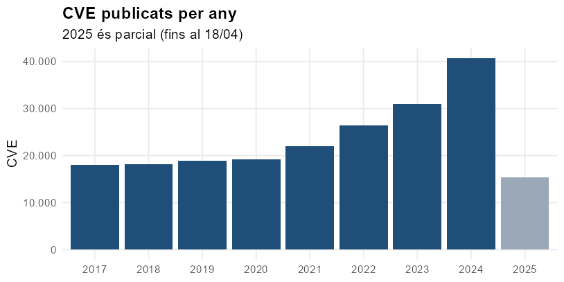

El 2025 és parcial (fins al 18/04/2025).

Bloc 2 · ggplot2 (3 de 7)

## *Aesthetics*: una variable més, un canal visual més

Posició, color (colour, el de fora), fill (el de dins), forma, tipus de línia i mida. Mapejar és posar una *variable* en un canal.

```
d <- cve |>
  filter(any >= 2017, any <= 2024) |>
  mutate(gravetat = coalesce(cvss3.severity,
                             "sense CVSS v3")) |>
  count(any, gravetat)

ggplot(d, aes(factor(any), n,
              fill = gravetat)) +    # aes
  geom_col()
```

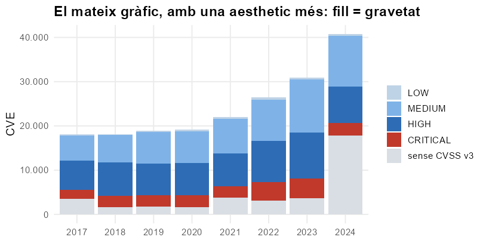

La mateixa dada amb fill = gravetat: creix la proporció «sense CVSS v3».

**Dins** d'aes() es mapeja una variable; **fora** es posa un valor fix (geom_col(fill = "#1F4E79")). Confondre-ho és l'error més comú.

Bloc 2 · ggplot2 (4 de 7)

## *Geoms*: el tipus de variable tria el gràfic

Cada *geom* només pinta els *aesthetics* que li toquen. Un gràfic en té un mínim; no hi ha màxim.

| Variables | *Geom* |
| --- | --- |
| Una quantitativa | geom_histogram() · geom_density() |
| Una categòrica | geom_bar() · geom_col() |
| Quantitativa per categories | geom_boxplot() · geom_violin() |
| Dues quantitatives | geom_point() · geom_count() · geom_tile() |
| Quantitativa en el temps | geom_line() · geom_point() |

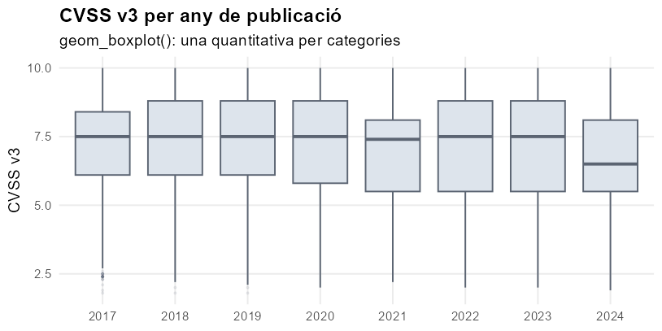

geom_boxplot(): la mediana ronda el 7,5 fins al 2023 i baixa el 2024.

```
d <- cve |> filter(any >= 2017, any <= 2024, !is.na(cvss3.score))
ggplot(d, aes(factor(any), cvss3.score)) + geom_boxplot()
```

Bloc 2 · ggplot2 (5 de 7)

## *Facets*: un panell per subconjunt

En comptes de pintar tres grups al mateix gràfic, es divideix en tres panells amb els mateixos eixos: comparar és molt més fàcil.

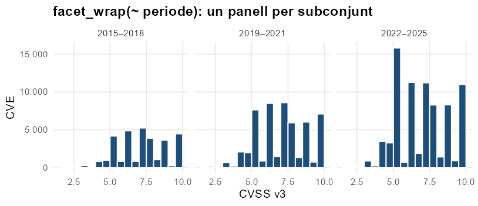

```
d <- cve |> filter(!is.na(cvss3.score), any >= 2015) |>
  mutate(periode = cut(any, c(2014, 2018, 2021, 2025),
                       labels = c("2015–2018", "2019–2021", "2022–2025")))

ggplot(d, aes(cvss3.score)) +
  geom_histogram(binwidth = 0.5, boundary = 0) +
  facet_wrap(~ periode, nrow = 1)
```

Bloc 2 · ggplot2 (6 de 7)

## Els CWE més freqüents (i com deixar el gràfic net)

problem.type és una cadena: les files *tidy* de la S3 (unnest_longer()) són el pas previ.

```
top <- cve.nist |>
  transmute(cve.id,
    cwe = str_extract_all(problem.type, "CWE-\\d+")) |>
  unnest_longer(cwe) |>
  count(cwe, sort = TRUE) |> slice_head(n = 10) |>
  left_join(cwe.weaknesses |>
    transmute(cwe = paste0("CWE-", ID), nom = Name),
    by = "cwe") |>
  mutate(etiqueta = fct_reorder(
    paste0(cwe, " · ", str_trunc(nom, 34)), n))

ggplot(top, aes(n, etiqueta)) +
  geom_col(fill = "#1F4E79") +
  labs(title = "Els 10 CWE més citats",
       x = "Mencions", y = NULL) +
  theme_minimal()
```

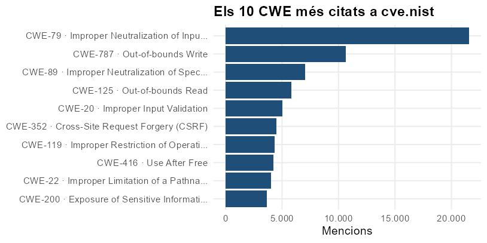

El rànquing compta **mencions**: un CVE pot citar un CWE més d'un cop.

Bloc 2 · ggplot2 (7 de 7)

## Escales, temes, ggsave() i on mirar més

01

Scales i statsTransformar

Cada *geom* porta una *stat* per defecte (count a geom_bar, bin a geom_histogram). Les *scales* canvien com es llegeix: scale_y_log10(), scale_fill_manual(), scale_x_date().

02

ThemesAspecte

Tot el que no són dades: theme_minimal(), theme(legend.position = "bottom"), labs() per a títols i eixos amb unitats.

03

Desar-hoSortida

ggsave("cvss.png", width = 7, height = 4) desa l'últim gràfic. Dins d'un .Rmd no cal: surt al .html.

04

Catàlegs i *cheat sheet*Consulta

El *cheat sheet* «Data visualization with ggplot2» (Posit). I, per triar el gràfic segons les teves dades: data-to-viz.com i datavizcatalogue.com.

Bloc 3 · Exercici 3

## Exploració visual del cas

Per equip. Parteixes de la taula del cas del 2b; no la refàs.

Enunciat

Almenys **tres gràfics** amb ggplot2 sobre cve.nist: (1) el CVSS de Log4Shell contra la distribució global; (2) els CVE que comparteixen CWE amb el cas; (3) la línia temporal dels CVE amb log4j a la description. Per cada gràfic, una frase: **què es veu** i **què no es pot concloure**.

Temps

20 mina classe, la resta a casa

Lliurable

.Rmd + .html al repo de l'equip, amb commit. Es lliura amb el pont (09/12, 23:59).

### Columnes que faràs servir

```
cvss3.score    cvss3.vector    published.date    description    problem.type
# Punt de partida: els chunks `cas` i `plataformes` de l'exercici 2b
```

Bloc 4 · Machine learning

## Un pas enrere: què és un model?

Fins ara hem descrit dades. Ara volem una màquina que **aprengui de l'experiència** (és una idea que s'atribueix a Alan Turing).

El fil de la S4 a la S5

Tot el que ve ara —funció, entrenament, regressió, classificació, xarxes— és el vocabulari de la S5. Si queda clar avui, a la S5 hi anem directes.

Bloc 4 · El problema

## Un projecte de ML existeix per resoldre un problema

Dues preguntes de tipus diferent:

01

«El PIB per càpita de Colòmbia és 13.441 $: quina puntuació té a l'Índex de Satisfacció amb la Vida?»Número

La resposta és un **valor** (5,71). És una **regressió**.

02

«Aquesta URL és *phishing*?» (http://activate.facebook.fblogins.net/…)Etiqueta

La resposta és una **classe** (sí / no). És una **classificació**.

03

«Quina nota CVSS té un CVE amb aquest vector?»El nostre cas

Les *features* de fa una estona (AV, AC, PR…) són l'**entrada**; la nota és la **resposta**.

Bloc 4 · El model

## Resoldre-ho és construir un model: una funció

Un model és una **abstracció** del problema: pren una entrada i torna una resposta.

13.441 $

entrada

MODEL

abstracció

5,71

resposta (regressió)

URL → MODEL → sí

entrada → resposta (classificació: *phishing*)

f (input) = answer

Bloc 4 · Entrenar

## Com aprèn un model?

Com aprèn a lligar unes entrades amb (esperem) les sortides correctes? Primer s'entrena; després es prova.

DADES D'ENTRENAMENT→ fase d'entrenament → MODEL→ MODEL ENTRENAT+ DADES DE PROVA → RESULTATS(fase de prova)

01

Les dades de prova no es veuen a l'entrenamentRegla

Un model mesurat amb les mateixes dades amb què s'ha entrenat sempre sembla bo. Per saber si **generalitza**, cal provar-lo amb dades que mai ha vist.

02

Pot aprendre?Pregunta

Depèn de si hi ha una relació a les dades, i de quantes en tenim.

Bloc 4 · Aprenentatge supervisat

## Dades d'entrenament amb la resposta inclosa

En l'aprenentatge **supervisat**, cada observació porta la seva resposta: l'*etiqueta* (*label*).

| cve.id | AV | AC | PR | UI | S | C | I | A | cvss3.score |
| --- | --- | --- | --- | --- | --- | --- | --- | --- | --- |
| CVE-1999-0199 | 3 | 1 | 2 | 1 | 0 | 2 | 2 | 2 | **9,8** |
| CVE-1999-0236 | 3 | 1 | 2 | 1 | 0 | 2 | 0 | 0 | **7,5** |
| CVE-2002-20001 | 3 | 1 | 2 | 1 | 0 | 0 | 0 | 2 | **7,5** |
| … 162.673 files |  |  |  |  |  |  |  |  | ← |

Les columnes **AV…A** són l'entrada; **cvss3.score** és la resposta. És l'exemple d'abans: un model que, donat un vector, torna una nota.

Bloc 4 · Veure una tendència

## Veus una tendència?

Abans de modelar, es dibuixa. Una entrada, una resposta, trenta observacions.

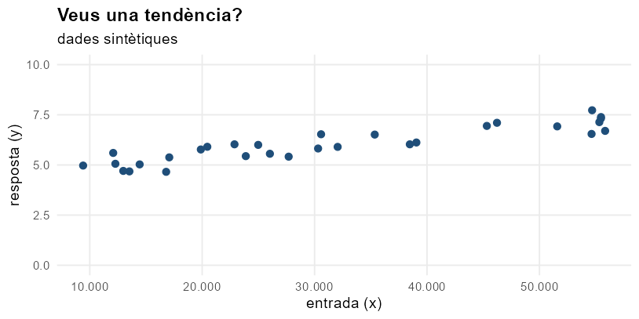

Dades sintètiques per il·lustrar; a 2023 era PIB per càpita i satisfacció amb la vida (països de l'OCDE).

Si veus una tendència, pots resumir-la amb una **funció**. La més senzilla és una recta.

Bloc 4 · Regressió lineal

## Una recta: dos números, θ₀ i θ₁

Un petit recordatori de l'escola: una recta és y = a·x + b. En ML s'escriu y = θ₀ + θ₁·x, i **aprendre** és trobar els dos números.

θ₀

on talla l'eix (el punt de partida)

θ₁

el pendent (quant puja *y* per cada unitat de *x*)

2

paràmetres que s'aprenen

Bloc 4 · No totes les rectes són bones

## Tres rectes, tres parelles de θ; només una té sentit

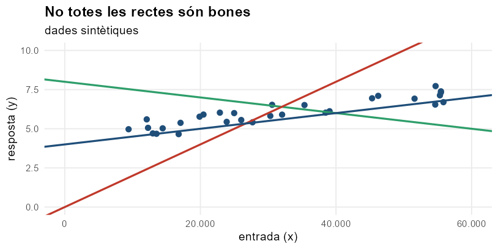

La verda baixa mentre les dades pugen; la vermella surt de les dades. Dades sintètiques.

Cal una manera de dir *quina* és la millor: una mesura de l'error.

Bloc 4 · La millor recta

## La millor recta és la que fa l'error més petit

L'error d'un punt és la distància vertical a la recta (el *residu*); es mesura sumant els quadrats de tots. Entrenar és buscar els θ que minimitzen aquesta suma.

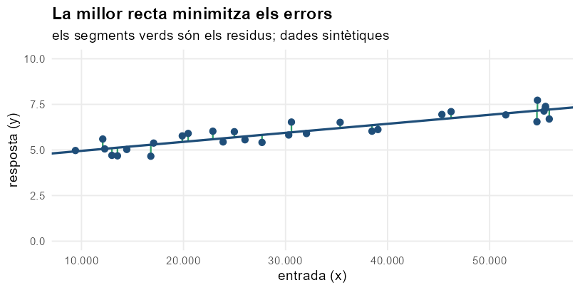

Aquest **error sobre les dades d'entrenament** és el que s'optimitza. Que sigui petit no vol dir que el model sigui bo amb dades noves.

Bloc 4 · *Trade-offs*

## El ML va de *trade-offs*

Si afegeixes països (punts) nous, la recta canvia: els extrems (rics i petits) la desplacen. Això passa en qualsevol model.

01

Simple contra flexibleComplexitat

Una recta s'equivoca en cada punt però entén tota la tendència. Un model molt flexible pot passar per tots els punts d'entrenament i fallar amb el següent: **sobreajust** (*overfitting*).

02

Més dades contra més exactitudCost

Més dades fan el model més estable; també més lent i més car d'entrenar.

03

No hi ha «el millor model»Decisió

Hi ha el millor per a **aquest** problema, aquestes dades i aquest cost de l'error. Decidir-ho és una feina humana.

Bloc 4 · Una presa de consciència

## La regressió lineal és perfectament simple, i només en té dues peces

Un model és una fórmula; el que se li pot demanar depèn de les entrades que té.

01

Amb una entrada: el PIB1 variable

«Donat 13.441 $, quina és la puntuació de Colòmbia?» Una recta.

02

Amb dues entrades: PIB i índex de Gini (51,3)2 variables

La mateixa pregunta, més informació: la recta passa a ser un **pla**. Més entrades, més bona resposta... si l'entrada té a veure amb la resposta.

Bloc 4 · *N* dimensions

## I així fins a *N* entrades

Dues entrades fan un pla en 3D; tres, un hiperpla que no es pot dibuixar; vuit, com els nostres CVE. L'idea és la mateixa i la fórmula també:

θ = (XᵀX)⁻¹ Xᵀ y

Això és tot el que fa lm(): calcula els θ d'un cop, sense iterar.

```
set.seed(2026)
prova <- sample(nrow(feat), round(0.2 * nrow(feat)))      # 20 % per a la prova
m <- lm(cvss3.score ~ AV + AC + PR + UI + S + C + I + A, data = feat[-prova, ])
round(coef(m), 2)
# (Intercept)    AV    AC    PR    UI     S     C     I     A
#        0.05  0.47  1.15  0.97  0.98  0.56  0.75  0.53  0.85

pred <- predict(m, feat[prova, ])
sqrt(mean((feat$cvss3.score[prova] - pred)^2))          # 0.46: error típic a la prova
# Log4Shell: real 10.0, predit 10.35  ·  CVE-2017-5645: real 9.8, predit 9.79
```

**130.138 CVE per entrenar, 32.535 per provar.** Nou paràmetres (un per entrada més el punt de partida) expliquen el 92,4 % de la variació de les dades d'entrenament. Les dades de prova són les que diuen si és bo.

Bloc 4 · Classificació

## Quan la resposta és una classe, no un número

Una regressió lineal torna qualsevol valor, també negatius i per sobre d'1. Per classificar, el model torna una **probabilitat**: la *regressió logística* és la corba en forma de S.

```
feat$critic <- feat$cvss3.score >= 9
g <- glm(critic ~ AV + AC + PR + UI + S + C + I + A,
         data = feat[-prova, ], family = binomial)
p <- predict(g, feat[prova, ], type = "response") > 0.5
mean(p == feat$critic[prova])
# 0.9897    (si diguéssim sempre «no crític»: 0.8474)
table(real = feat$critic[prova], predit = p)
#        predit
# real    FALSE  TRUE
#   FALSE 27464   106
#   TRUE    228  4737
```

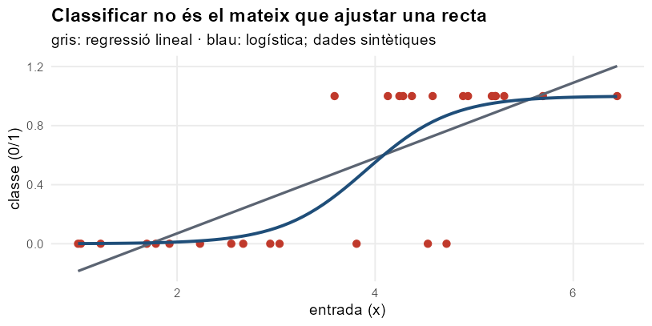

Dades sintètiques. La recta surt de 0–1; la logística, no.

**Una exactitud sola enganya:** un 84,7 % és el que treu qui diu sempre «no». Cal mirar la matriu de confusió i, sobretot, les **228** crítiques que el model no veu.

Bloc 4 · Addendum

## Classification with Neural Networks

Una xarxa neuronal és una funció més flexible: moltes capes de funcions simples (neurones) encadenades. És el pas següent, i és on comença la S5.

```
library(nnet)
fs <- feat |> mutate(across(AV:A, ~ .x / max(.x)))     # escalat 0–1
nn <- nnet(critic ~ AV + AC + PR + UI + S + C + I + A,
           data = fs[-prova, ], size = 4, decay = 1e-3, maxit = 300)
pn <- predict(nn, fs[prova, ]) > 0.5
mean(pn == fs$critic[prova])
# 0.9999    (41 paràmetres; 15 s; no ha convergit del tot en 300 iteracions)
#        predit
# real    FALSE  TRUE
#   FALSE 27568     2
#   TRUE      1  4964
```

[figure not shown]

8 entrades (AV…A) → 4 neurones ocultes → 1 sortida (crític: sí/no). 41 paràmetres.

**Què s'ha aprés, i què no.** La xarxa passa del 98,97 % al 99,99 % perquè la nota CVSS és una fórmula no lineal que les *features* determinen del tot. No ha «entès» la seguretat; ha après una funció. Un LLM és la mateixa idea amb milers de milions de paràmetres.

Bloc 5 · *Clustering* (1 de 2)

## Sense etiquetes: agrupar per semblança

Fins ara cada observació portava la resposta. En l'aprenentatge **no supervisat** no n'hi ha: l'algorisme troba grups. **K-means** divideix les dades en *K* grups.

1. **Triar K i els centroides inicials**K punts a l'atzar (per això s'usa set.seed()).
2. **Assignar**Cada observació, al centroide més proper.
3. **Recalcular**Cada centroide passa a ser la mitjana del seu grup.
4. **Repetir**Fins que els grups no canvien.

Requisits: una **distància** (l'euclidiana), un **K** (el triem nosaltres) i dades **numèriques i a la mateixa escala**. Per això el bloc 1 era *feature engineering*.

Bloc 5 · *Clustering* (2 de 2)

## Grups de CVE per perfil CVSS: 15 minuts

```
Xs <- feat |> select(AV:A) |>
  mutate(across(everything(), ~ .x / max(.x)))     # escalat 0–1

set.seed(2026)
km <- kmeans(Xs, centers = 4, nstart = 10)
table(km$cluster)
#     1     2     3     4
# 26124 37974 68210 30365

round(km$centers, 2)
#     AV   AC   PR   UI    S    C    I    A
# 1 0.74 0.95 0.80 0.79 0.03 0.05 0.06 0.97
# 2 0.84 0.92 0.76 0.90 0.02 0.69 0.25 0.02
# 3 0.77 0.94 0.76 0.74 0.03 1.00 1.00 1.00
# 4 0.99 0.99 0.72 0.03 0.88 0.46 0.54 0.02
```

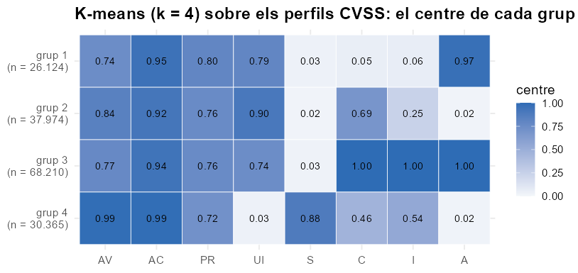

Bloc 5 · Llegir els grups

## Què hi ha a cada grup: es llegeixen els centres

3

Impacte total (C, I i A alts)68.210 CVE

Aquí hi són **els dos CVE del cas**. Mediana CVSS 8,8.

1

Denegació de servei (només A)26.124 CVE

Cal llegir els centres, no els números dels grups: la numeració pot canviar amb la llavor.

4

Cal que l'usuari interactuï, abast canviat30.365 CVE

Sovint és *cross-site scripting*: l'usuari fa clic.

2

Fuga d'informació (C)37.974 CVE

**K el tries tu.** Amb K = 4 els grups tenen sentit de seguretat; amb 3 o 7 en tindrien un altre. K-means **no** et diu quants n'hi ha. Les dades són **a la mateixa escala** perquè sinó l'AV (0–3) pesaria més que l'AC (0–1).

Bloc 6 · El graf d'estàndards (1 de 5)

## build_network() per defecte no conté el cas

Els estàndards no s'enllacen només per text dins de columnes (S3): mitre els converteix en un **graf**. Però, sense arguments, el graf surt d'una **mostra interna aleatòria** del paquet.

```
g0 <- mitre::build_network(as_igraph = TRUE)       # sense arguments: la mostra interna
igraph::vcount(g0); igraph::ecount(g0)
# 1010 nodes, 1643 arestes (1,6 s)
"CVE-2021-44228" %in% igraph::V(g0)$label            # FALSE
"CVE-2017-5645"  %in% igraph::V(g0)$label            # FALSE
```

La mostra té **422 CVE** (el 0,2 % de cve.nist) i un 30 % de CWE i CAPEC, tot a l'atzar. Ni Log4Shell ni el control hi són, i la cadena CVE → CWE → CAPEC → ATT&CK queda trencada pel mostreig. Per al cas, **construïm la nostra llista standards**.

Bloc 6 · El graf d'estàndards (2 de 5)

## La llista standards del cas

Només es **filtren CVE i CPE**. CWE, CAPEC, ATT&CK, SHIELD, Engage i CAR van **completes** (són petites): així la cadena no es trenca per un mostreig.

```
library(mitre)
cve <- dplyr::filter(cve.nist, cve.id %in% c("CVE-2021-44228", "CVE-2017-5645") |
                     grepl("log4j", description, ignore.case = TRUE))
# Sentinelles: build_cve2cwe_edges() (dds-2026) buida TOTES les arestes CVE-CWE si el conjunt
# no té cap 'NVD-CWE-noinfo' ni cap 'NVD-CWE-Other'. Les sentinelles no tenen arestes i el graf les descarta.
sent <- cve.nist[cve.nist$problem.type %in% c('["NVD-CWE-noinfo"]', '["NVD-CWE-Other"]') &
                 !cve.nist$cve.id %in% cve$cve.id, ]
cve <- rbind(cve, sent[!duplicated(sent$problem.type), ])
cpe <- dplyr::filter(cpe.nist, product == "log4j")
s <- list(
  cpe   = list(cpe.nist = cpe),
  cve   = list(cve.nist = cve),
  cwe   = list(cwe.views = cwe.views, cwe.categories = cwe.categories, cwe.weaknesses = cwe.weaknesses),
  capec = list(capec.views = capec.views, capec.categories = capec.categories,
               capec.patterns = capec.patterns, capec.relations = capec.relations),
  attck = list(attck.tactics = attck.tactics, attck.techniques = attck.techniques,
               attck.mitigations = attck.mitigations, attck.groups = attck.groups,
               attck.software = attck.software, attck.data_component = attck.data_component,
               attck.data_relations = attck.data_relations, attck.relations = attck.relations),
  shield = list(shield.tactics = shield.tactics, shield.techniques = shield.techniques,
                shield.procedures = shield.procedures, shield.use_cases = shield.use_cases,
                shield.opportunities = shield.opportunities, shield.relations = shield.relations),
  engage = list(engage.goals = engage.goals, engage.approaches = engage.approaches,
                engage.activities = engage.activities, engage.av = engage.av, engage.relations = engage.relations),
  car = list(car.analytics = car.analytics, car.model = car.model, car.coverage = car.coverage,
             car.implementations = car.implementations, car.sensors = car.sensors, car.relations = car.relations)
)
# build_capec_nodes() i build_cwe2cwe_edges() (dds-2026) llegeixen el 'standards' del paquet (la mostra)
# i no l'argument: sense això, CAPEC i CWE-CWE surten de la mostra i la cadena es trenca.
utils::assignInNamespace("standards", s, ns = "mitre")
net <- build_network(standards = s, as_igraph = TRUE)
```

Bloc 6 · El graf d'estàndards (3 de 5)

## Per què hi ha tres línies que no són de la llista

Dos errors de build_network() a la branca dds-2026 (mitre 1.0.0.9100) que només surten amb una llista pròpia. Les línies de la dreta són el pegat de l'aula.

01

Sense sentinelles, cap aresta CVE → CWEError

build_cve2cwe_edges() fa x[-which(…), ]. Si el conjunt no té cap NVD-CWE-Other, which() torna buit i la taula queda **buida**: el CVE no arriba a cap CWE. Les sentinelles són dos CVE del conjunt complet, sense arestes, que el graf descarta.

02

Sense assignInNamespace(), CAPEC de la mostraError

03

Què passa si no es posenEfecte

Amb la llista pròpia però sense les línies: **3.267** nodes, CVE-2017-5645 no surt al graf i Log4Shell no arriba a cap tècnica. Amb elles, tot connecta.

El pegat és de l'aula: no canvia el paquet. La correcció neta és al codi de mitre; fins llavors, aquestes línies són part de la recepta i van al pont.

Bloc 6 · El graf d'estàndards (4 de 5)

## Què hi ha al graf del cas

Resultat d'executar la llista de la diapositiva anterior (R 4.6.1, mitre 1.0.0.9100, Windows).

4.145

nodes

30.230

arestes (dirigides)

≈ 8 s

llista + graf (el build_network() sol: ≈ 2 s)

≈ 1,5 GB

memòria màxima del procés R

| Estàndard | Nodes | Notes |
| --- | --- | --- |
| cwe | 1.353 | 943 debilitats, 374 categories, 36 vistes |
| attck | 1.620 | tàctiques, tècniques, mitigacions… |
| capec | 558 | patrons, categories, vistes |
| shield | 384 |  |
| car | 131 |  |
| engage | 74 |  |
| cve | 19 | dels 24 filtrats; 5 sense arestes es descarten |
| cpe | 6 | de 132 log4j: només els enllaçats |

**Els nodes d'igraph no tenen l'identificador al name sinó al label**: el name és un número intern. Un CVE es busca amb V(net)[label == "CVE-2021-44228"]. Arestes: **22** CVE → CWE, **14** CVE → CPE, **1.212** CWE → CAPEC, **271** CAPEC → ATT&CK.

Bloc 6 · El graf d'estàndards (5 de 5)

## Travessar el graf amb igraph

shortest_paths() dona el camí més curt; distances(), a quantes passes és cada node.

```
library(igraph)
tec <- V(net)[group == "attck" & type == "technique"]
cas <- V(net)[label == "CVE-2021-44228"]

d <- distances(net, cas, tec, mode = "out")
table(d[is.finite(d)])                      # tècniques per nombre de passes
#  3  4  5  6  7  8
#  8 29 57 75 20  5                          # 194 tècniques accessibles

p <- shortest_paths(net, from = cas, to = tec[which.min(d)], mode = "out")$vpath[[1]]
V(net)$label[p]
# "CVE-2021-44228" "CWE-20" "CAPEC-13" "T1574.007"
V(net)$title[tec[which.min(d)]]             # "Path Interception by PATH Environment Variable"
```

**El camí més curt no és el més significatiu:** CWE-20 és una categoria molt àmplia. I el CVE de control, CVE-2017-5645 (només CWE-502), no arriba a cap tècnica en menys de **5** passes, i per la jerarquia de CWE (CWE-502 → CWE-913 → CWE-664), no pel patró d'atac que el descriu. Que el graf «hi arribi» no vol dir que la resposta sigui bona.

Bloc 6 · L'exercici-pont

## Travessar el cas a mà, amb el graf

Per equip, durant la setmana del 7/12. Lliurament: **dimecres 09/12, 23:59**. Enunciat i plantilla a 04-S4/pont/.

Pas 0 · i després

**Pas 0:** construir la llista standards del cas (CVE i CPE filtrats, la resta de taules completes). No s'usa build_network() per defecte. **Després:** (a) el subgraf del cas, (b) la llista de CWE, CAPEC i tècniques trobades, (c) les **5 preguntes** de sota, **respostes només amb el graf**, i per a cadascuna **si el graf hi arriba o no**. Per a CVE-2021-44228 i CVE-2017-5645.

Les 5 preguntes

1. Quins CWE té el CVE?  
2. Quins patrons d'atac (CAPEC) demostren aquests CWE?  
3. Quines tècniques ATT&CK implementen aquests patrons?  
4. Quins productes o plataformes (CPE) són afectats?  
5. Quines mitigacions o defenses hi ha enllaçades?

«El graf no hi arriba» és una resposta correcta si és el que veus. És la **línia base**: la S5 la contrasta amb un model de llenguatge i la S7 amb un sistema fonamentat en coneixement.

Apèndix

## Noms que sentireu

Una línia cadascun.

**feature**

Variable construïda per a un model.

**label**

La resposta correcta d'una observació d'entrenament.

**train / test**

Dades per entrenar i dades per provar; no es barregen.

**overfitting**

El model es memoritza l'entrenament i falla amb dades noves.

**residu**

La distància d'un punt a la recta.

**centroide**

El centre d'un grup, a K-means.

**neurona, capa, pesos**

Les peces d'una xarxa neuronal; els pesos són els paràmetres.

**aesthetic · geom · facet**

Els tres verbs bàsics de ggplot2.

**qplot**

Interfície antiga de ggplot2; ja no es fa servir.

Material i referències

## Per continuar

### Material de la sessió

- **Enunciat de l'exercici 3** — repositori d'alumnes, 04-S4/exercici-3/
- **Exercici-pont** — 04-S4/pont/ENUNCIAT.md i plantilla .Rmd
- **Plantilla .Rmd** — templates/dds-template.Rmd
- **Taula del cas** — els *chunks* cas i plataformes de l'exercici 2b

### Referències

- **mitre** — github.com/DDS-MCSM/mitre, branca dds-2026
- **igraph per a R** — r.igraph.org
- **R for Data Science** — Wickham, Çetinkaya-Rundel, Grolemund (visualització, cap. 1)
- **Triar el gràfic** — data-to-viz.com · datavizcatalogue.com

Bloc compliance · 10 min

## Abans de tancar

Si un model s'equivoca, qui se n'adona?

Concepte

Un model és una funció apresa de dades. Sense dades de prova, no hi ha manera de saber si s'equivoca; i amb dades de prova, només se sap *on s'ha provat*. L'exactitud del 99,99 % d'avui és sobre una fórmula coneguda; amb un CVE nou i un perfil que el model no va veure, ningú no ho sap.

Enllaç

A la S5 el «model» serà un de llenguatge: el mateix principi (f(input) = answer), amb un cost d'equivocar-se que no és una nota CVSS. La pregunta de qui es fa responsable de la resposta —qui firma— hi torna.

Tancament de la Part 1 · Anuncis

## Abans de la S5: dues coses

Aquí acaba la part d'**Arnau**. Dijous 10/12 comença la S5, amb l'**Humbert**: de com aprèn un model a un sistema d'IA.

01

Instal·la LM Studio abans de dijousS5 · 10/12

Segueix la guia de 05-S5/ del repositori d'alumnes. Serveix per fer córrer models de llenguatge al teu portàtil. Si no pots instal·lar-lo, ho dius abans de la sessió.

02

Lliura el pont: dimecres 09/12, 23:59Lliurament

Per equip: 04-S4/pont/ENUNCIAT.md i la plantilla .Rmd. Construeix la llista standards del cas, travessa el graf i respon les 5 preguntes. És el punt de partida de la S5.